# Implementasi Teknik Web Scraping dan Analisis Clustering pada Data Top 500 IMDb US Box Office Movies

Azka Muhammad Radinka Purba - Aubert Oktaviantono

1/7/2021

# Overview Project

Penulis melakukan web scraping untuk pengambilan data 500 film teratas di website IMDb dan melakukan analisis K-means clustering menggunakan bahasa pemrograman R dalam aplikasi RStudio. Metode K-Means Clustering dipilih dalam analisis ini karena penulis ingin mengelompokkan data Top 500 IMDb US Box Office Movies menjadi beberapa label pengelompokkan yang jelas dari jumlah pendapatan kotor, nilai Rating, nilai Metascore, durasi film, dan jumlah vote yang didapatkan. Selain itu metode K-means clustering merupakan metode yang umum untuk analisis clustering.

Analisis menggunakan metode web scraping dan K-means clustering bertujuan sebagai media belajar penulis dalam menggunakan metode web scraping dan K-means clustering untuk mengambil data dari internet dan mengelompokkan data 500 film teratas di website IMDb menjadi beberapa cluster dengan karakteristik tertentu berdasarkan variabel jumlah pendapatan kotor, nilai Rating, nilai Metascore, durasi film, dan jumlah vote yang didapatkan. Selain itu analisis ini juga menjadi media belajar penulis dalam membuat dashboard dan markdown sebagai media untuk menampilkan hasil dari eksplorasi data dan analisis cluster dalam analisis ini.

## Sumber Data

Dalam analisis ini, data yang digunakan adalah data [**IMDB Top 1000 Film**](https://www.imdb.com/search/title/?groups=top_1000&s%20ort=boxoffice_gross_us,desc) yang diurutkan berdasarkan US Box Office. Data diambil pada tanggal 25 Desember 2020 pukul 20.00 WIB.

## Langkah Analisis

1. Scrapping Data
2. Pra-Pemrosesan Data
3. Eksplorasi Data
4. Clustering
5. Menarik Kesimpulan Saran dan Rekomendasi

### Library yang digunakan

```r
### Scraping
library(xml2)
library(rvest)

### Pra-Pemrosesan Data
library(stringr)
library(rebus)
library(writexl)

### Data Wrangling
library(tidyverse)
library(readxl)
library(BBmisc)
library(purrr)
library(data.table)

### Visualisasi
library(radarchart)
library(grDevices)
library(plotly)
library(DT)
library(fmsb)
library(cowplot)
library(dygraphs)
library(formattable)
library(ggpubr)

### Clustering
library(NbClust)
library(factoextra)

### Dashboard
library(knitr)
library(shiny)
library(shinydashboard)
library(flexdashboard)
```

## 1. Scraping

Dilakukan scrapping [**IMDB Top 1000 Film**](https://www.imdb.com/search/title/?groups=top_1000&s%20ort=boxoffice_gross_us,desc), dilakukan looping terhadap 12 laman yang ada

```r
url_cluster <- c('https://www.imdb.com/search/title/?groups=top_1000&sort=boxoffice_gross_us,desc&ref_=adv_prv',
                 'https://www.imdb.com/search/title/?groups=top_1000&sort=boxoffice_gross_us,desc&start=51&ref_=adv_nxt',
                 'https://www.imdb.com/search/title/?groups=top_1000&sort=boxoffice_gross_us,desc&start=101&ref_=adv_nxt',
                 'https://www.imdb.com/search/title/?groups=top_1000&sort=boxoffice_gross_us,desc&start=151&ref_=adv_nxt',
                 'https://www.imdb.com/search/title/?groups=top_1000&sort=boxoffice_gross_us,desc&start=201&ref_=adv_nxt',
                 'https://www.imdb.com/search/title/?groups=top_1000&sort=boxoffice_gross_us,desc&start=251&ref_=adv_nxt',
                 'https://www.imdb.com/search/title/?groups=top_1000&sort=boxoffice_gross_us,desc&start=301&ref_=adv_nxt',
                 'https://www.imdb.com/search/title/?groups=top_1000&sort=boxoffice_gross_us,desc&start=351&ref_=adv_nxt',
                 'https://www.imdb.com/search/title/?groups=top_1000&sort=boxoffice_gross_us,desc&start=401&ref_=adv_nxt',
                 'https://www.imdb.com/search/title/?groups=top_1000&sort=boxoffice_gross_us,desc&start=451&ref_=adv_nxt',
                 'https://www.imdb.com/search/title/?groups=top_1000&sort=boxoffice_gross_us,desc&start=501&ref_=adv_nxt',
                 'https://www.imdb.com/search/title/?groups=top_1000&sort=boxoffice_gross_us,desc&start=551&ref_=adv_nxt'
)

Title <- c()
Metascore <- c()
Rating <- c()
Synopsis <- c()
Votes <- c()
Gross <- c()
Runtime <- c()
Genre <- c()
Director <- c()
Director_and_stars <- c()
Image <- c()
Age_Rate <- c()

for(i in url_cluster){
  html <- read_html(i)
  title <- html %>% html_nodes('.lister-item-header') %>% html_text()
  metascore <- html %>% html_nodes('.metascore') %>% html_text()
  rating <- html %>% html_nodes('.ratings-imdb-rating strong') %>% html_text()
  synopsis <- html %>% html_nodes('.ratings-bar+ .text-muted') %>% html_text()
  votes <- html %>% html_nodes('.sort-num_votes-visible span:nth-child(2)') %>% html_text()
  gross <- html %>% html_nodes('.ghost~ .text-muted+ span') %>% html_text()
  runtime <- html %>% html_nodes('.runtime') %>% html_text()
  genre <- html %>% html_nodes('.genre') %>% html_text()
  director <- html %>% html_nodes('.text-muted+ p a:nth-child(1)') %>% html_text()
  director_and_stars <- html %>% html_nodes('.text-muted+ p') %>% html_text()
  image <- html %>% html_nodes('#main .loadlate') %>% as.character() %>% str_extract('https:.*jpg')

  Title <- append(Title, title)
  Metascore <- append(Metascore, metascore)
  Rating <- append(Rating, rating)
  Synopsis <- append(Synopsis, synopsis)
  Votes <- append(Votes, votes)
  Gross <- append(Gross, gross)
  Runtime <- append(Runtime, runtime)
  Genre <- append(Genre, genre)
  Director <- append(Director, director)
  Director_and_stars <- append(Director_and_stars, director_and_stars)
  Image <- append(Image, image)
}

df <- tibble(Title, Rating, Synopsis, Votes, Gross,
             Runtime, Genre, Director, Director_and_stars)
```

### Raw data

```r
glimpse(df)
```

```
## Rows: 600
## Columns: 9
## $ Title              <chr> "\n        1.\n    \n    Star Wars: Episode VII ...
## $ Rating             <chr> "7.9", "8.4", "7.8", "8.4", "7.8", "8.0", "7.6",...
## $ Synopsis           <chr> "\n    As a new threat to the galaxy rises, Rey,...
## $ Votes              <chr> "858,688", "800,050", "1,116,552", "828,327", "1...
## $ Gross              <chr> "$936.66M", "$858.37M", "$760.51M", "$678.82M", ...
## $ Runtime            <chr> "138 min", "181 min", "162 min", "149 min", "194...
## $ Genre              <chr> "\nAction, Adventure, Sci-Fi            ", "\nAc...
## $ Director           <chr> "J.J. Abrams", "Anthony Russo", "James Cameron",...
## $ Director_and_stars <chr> "\n    Director:\nJ.J. Abrams\n                 ...
```

## 2. Pra-Pemrosesan Data

Pada tahap ini terdapat beberapa hal yang akan dilakukan diantaranya adalah :

- Membersihkan space dan tab yang terdapat pada kolom title.
- Membuat variabel tahun dengan mengekstrak dari kolom title menggunakan regular expression.
- Membersihkan space dan tab yang terdapat pada kolom synopsis.
- Mengubah tipe data votes menjadi tipe data numerik dengan pemisah desimal menggunakan titik.
- Membersihkan kolom gross dari lambang dollar dan huruf M, dan mengubahnya ke tipe data numerik
- Membersihkan kolom runtime dengan menghapus space dan kata “min”, lalu mengubahnya ke tipe data numerik.
- Memisahkan kolom genre film menjadi 3 kolom dikarenakan data genre film yang didapat bervariasi dari 1 genre hingga 3 genre untuk 1 film.
- Terdapat beberapa film yang tidak memiliki metascore, sehingga film-film tersebut di drop dari dataframe. Jumlah film yang diambil dikurangi menjadi 500 film atas dasar keinginan penulis agar angkanya bulat.

```r
# Rating
df$Rating=as.numeric(df$Rating)
# Votes
df$Votes=as.numeric(gsub(",","",df$Votes))
# Gross
df$Gross=gsub("M","",df$Gross)
df$Gross=as.numeric(substring(df$Gross,2,6))
# Runtime
df$Runtime=as.numeric(gsub(" min","",df$Runtime))
# Year
df$Year=str_extract(df$Title, DGT%R%DGT%R%DGT%R%DGT)
# Title
df$Title=str_sub(df$Title,start=22, end = -13)
df$Title=str_trim(df$Title, side = "both")
# Genre
mgenre = str_split(df$Genre, pattern = ", ", simplify = T)
mgenre=gsub("\\n","",mgenre)
mgenre=gsub(" ","",mgenre)
df$Genre_1=mgenre[,1]
df$Genre_2=mgenre[,2]
df$Genre_3=mgenre[,3]
df=df[, -7]
# Stars
stars=gsub(".*Stars:","",df$Director_and_stars)
stars=gsub("\n","",stars)
stars=str_trim(stars,side = "both")
stars=str_split(stars, pattern = ", ", simplify = T)
df=df[,-8]
df$Stars_1=stars[,1]
df$Stars_2=stars[,2]
df$Stars_3=stars[,3]
df$Stars_4=stars[,4]

drop=c('The Ten Commandments',
          "The Lion in Winter",
          "Baahubali 2: The Conclusion",
          "Dangal",
          "Zelig",
          "The Red Shoes",
          "PK",
          "The Quiet Man",
          "The Lost Weekend",
          "Bajrangi Bhaijaan",
          "Witness for the Prosecution",
          "Bãhubali: The Beginning",
          "The Big Sleep",
          "Batman: Mask of the Phantasm",
          "The Gold Rush",
          "The Kid",
          "Once Upon a Time in America",
          "Hamlet",
          "Laura")

for (i in drop){
  df=df[!df$Title==i,]
}

df['Metascore'] = Metascore
df$Metascore=as.numeric(df$Metascore)
df <- df[-c(501:581),]
write_xlsx(df, 'data.xlsx')
```

Clean Data

```r
glimpse(df)
```

```
## Rows: 500
## Columns: 16
## $ Title     <chr> "Star Wars: Episode VII - The Force Awakens", "Avengers: ...
## $ Rating    <dbl> 7.9, 8.4, 7.8, 8.4, 7.8, 8.0, 7.6, 9.0, 7.8, 8.4, 7.8, 7....
## $ Synopsis  <chr> "\n    As a new threat to the galaxy rises, Rey, a desert...
## $ Votes     <dbl> 858688, 800050, 1116552, 828327, 1042468, 1257879, 248465...
## $ Gross     <dbl> 936.6, 858.3, 760.5, 678.8, 659.3, 623.2, 608.5, 534.8, 5...
## $ Runtime   <dbl> 138, 181, 162, 149, 194, 143, 118, 152, 133, 164, 115, 10...
## $ Director  <chr> "J.J. Abrams", "Anthony Russo", "James Cameron", "Anthony...
## $ Year      <chr> "2015", "2019", "2009", "2018", "1997", "2012", "2018", "...
## $ Genre_1   <chr> "Action", "Action", "Action", "Action", "Drama", "Action"...
## $ Genre_2   <chr> "Adventure", "Adventure", "Adventure", "Adventure", "Roma...
## $ Genre_3   <chr> "Sci-Fi", "Drama", "Fantasy", "Sci-Fi", NA, "Sci-Fi", "Ad...
## $ Stars_1   <chr> "Daisy Ridley", "Robert Downey Jr.", "Sam Worthington", "...
## $ Stars_2   <chr> "John Boyega", "Chris Evans", "Zoe Saldana", "Chris Hemsw...
## $ Stars_3   <chr> "Oscar Isaac", "Mark Ruffalo", "Sigourney Weaver", "Mark ...
## $ Stars_4   <chr> "Domhnall Gleeson", "Chris Hemsworth", "Michelle Rodrigue...
## $ Metascore <dbl> 80, 78, 83, 68, 75, 69, 80, 84, 65, 78, 91, 84, 88, 92, 7...
```

## 3. Eksplorasi Data

### Genre Terbanyak

```r
df_long <- gather(df, genre_, Genre, Genre_1:Genre_3, factor_key = TRUE)
df_genre <- df_long %>%
  drop_na() %>%
  group_by(Genre) %>%
  mutate(n = 1) %>%
  summarise(Metascore = mean(Metascore), Runtime = mean(Runtime), Rating = mean(Rating), `Jumlah Film` = sum(n))
```

```r
p <- ggplot(df_genre, aes(reorder(Genre, -`Jumlah Film`), `Jumlah Film`, fill = `Jumlah Film`)) +
  geom_bar(stat = 'identity') +
      labs(x = "Genre Film", y = "Jumlah Film",
       title = "Genre Terbanyak",
       caption = "Data IMDB Top 500 Box Office") +
  theme(legend.position = "none", panel.grid = element_blank(), rect = element_blank(),
        title = element_text(color = "#1B3A4B"),
        plot.title = element_text(size = 18, face = "bold"),
        text = element_text(size = 12),
        plot.caption = element_text(size = 8)) +
  coord_flip() +
  scale_fill_gradient2(low = "#EFD05F", high = "#B89412", mid = "#E2B616", midpoint = 70)
ggplotly(p)
```

[interactive chart not shown]

Gambar menunjukkan bar chart untuk jumlah film pada setiap genre film yang masuk kedalam top 500 IMDB Box Office. Dapat diketahui bahwa genre drama merupakan genre film yang paling banyak masuk kedalam top 500 IMDB Box Office. Selisih genre drama sebagai genre terbanyak dengan genre adventure yang berada di posisi kedua berbeda cukup jauh yakni 2 kali lipatnya.

### Kombinasi Genre Terbanyak

```r
df1 <- df %>%
  count(Genre_1, Genre_2, Genre_3, sort = TRUE)
#df$`Kombinasi Genre` <- paste(c(df$Genre_1, df$Genre_2, df$Genre3), collapse = ",")
df1$`Kombinasi Genre` = paste(df1$Genre_1, df1$Genre_2, df1$Genre_3)

df1$`Kombinasi Genre` <- gsub(' NA', '', df1$`Kombinasi Genre`)
df1$`Kombinasi Genre` <- gsub(' ', ' - ', df1$`Kombinasi Genre`)
df_gb <- df1 %>%
  rename(`Jumlah Film`= n) %>%
  select(`Kombinasi Genre`, `Jumlah Film`) %>%
  filter(`Jumlah Film` > 8)
p <- ggplot(df_gb, aes(reorder(`Kombinasi Genre`, -`Jumlah Film`), `Jumlah Film`, fill = `Jumlah Film`)) +
  geom_bar(stat = 'identity') +
      labs(x = "Genre Film", y = "Jumlah Film",
       title = "Kombinasi Genre Terbanyak",
       caption = "Data IMDB Top 500 Box Office") +
  theme(legend.position = "none", panel.grid = element_blank(), rect = element_blank(),
        title = element_text(color = "#1B3A4B"),
        plot.title = element_text(size = 18, face = "bold"),
        text = element_text(size = 12),
        plot.caption = element_text(size = 8)) +
  coord_flip() +
  scale_fill_gradient2(low = "#EFD05F", high = "#B89412", mid = "#E2B616", midpoint = 15)
ggplotly(p)
```

[interactive chart not shown]

Gambar menunjukkan bar chart untuk jumlah film pada setiap kombinasi genre film yang masuk kedalam top 500 IMDB Box Office. Dapat diketahui bahwa film yang bergenre drama tanpa kombinasi dengan genre lain merupakan film yang paling banyak masuk kedalam top 500 IMDB Box Office

### Runtime vs Gross

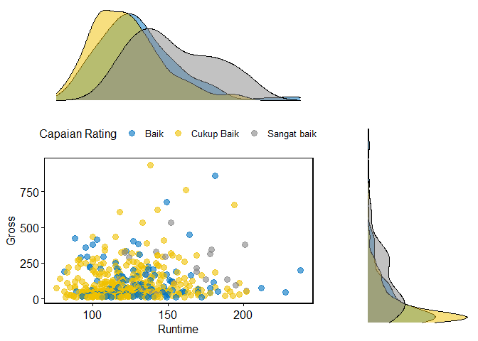

```r
df1 <- df
df1$`Capaian Rating` = cut(df1$Rating, breaks = c(0, 8, 8.5, 10),
                        include.lowest = TRUE,
                        labels = c(1:3))
df1$`Capaian Rating` <- as.character(df1$`Capaian Rating`)
df1 <- df1 %>%
  mutate(`Capaian Rating` = replace(`Capaian Rating`, `Capaian Rating`=='1', 'Cukup Baik')) %>%
  mutate(`Capaian Rating` = replace(`Capaian Rating`, `Capaian Rating`=='2', 'Baik')) %>%
  mutate(`Capaian Rating` = replace(`Capaian Rating`, `Capaian Rating`=='3', 'Sangat baik'))
# Scatter plot colored by groups ("Species")

sp <- ggscatter(df1, x = "Runtime", y = "Gross",
              color = "Capaian Rating", palette = "jco",
              size = 3, alpha = 0.6)+
border()
# Marginal density plot of x (top panel) and y (right panel)
xplot <- ggdensity(df1, "Runtime", fill = "Capaian Rating",
                 palette = "jco")
yplot <- ggdensity(df1, "Gross", fill = "Capaian Rating",
                   palette = "jco")+
rotate()
# Cleaning the plots
# sp <- sp + rremove("legend")
yplot <- yplot + clean_theme() + rremove("legend")
xplot <- xplot + clean_theme() + rremove("legend")
  #  Arranging the plot using cowplot

plot_grid(xplot, NULL, sp, yplot, ncol = 2, align = "hv",
          rel_widths = c(2, 1), rel_heights = c(1, 2))
```

Gambar menunjukkan sebaran data variabel runtime dan gross untuk setiap capaian rating yang terbagi atas capaian cukup baik (rating < 8), capaian baik (rating 8-8.5), dan capaian rating sangat baik (8.5-10). Dapat dilihat dari histogram yang berada di atas dan di sebelah kanan scatterplot bahwa film dengan rating yang sangat baik memiliki sebaran data dengan gross dan runtime yang lebih tinggi jika dibandingkan dengan sebaran data film dengan capaian cukup baik dan baik. Dapat dikatakan film-film dengan capaian rating yang sangat baik memiliki rata-rata gross yang tinggi.

### Top Director

```r
dfd <- df %>%
  count(Director, sort = TRUE) %>%
  rename(`Jumlah Film` = n)
dfd
```

```
## # A tibble: 284 x 2
##    Director          `Jumlah Film`
##    <chr>                     <int>
##  1 Steven Spielberg             14
##  2 Christopher Nolan             8
##  3 Clint Eastwood                8
##  4 David Fincher                 8
##  5 Martin Scorsese               7
##  6 Quentin Tarantino             7
##  7 Woody Allen                   7
##  8 Ridley Scott                  6
##  9 Wes Anderson                  6
## 10 James Cameron                 5
## # ... with 274 more rows
```

### Film dan Radar Chart Steven Spielberg

```r
df_stee <- df %>%
  filter(Director == "Steven Spielberg") %>%
  select(Title, Rating, Metascore, Gross, Votes)
formattable(df_stee,
            list(area(col = c(Metascore)) ~ normalize_bar("pink", 0.9),
                 area(col = c(Gross)) ~ normalize_bar("orange", 0.5),
                 area(col = c(Rating)) ~ normalize_bar("yellow", 0.9),
                 area(col = c(Votes)) ~ normalize_bar("#EFD05F", 0.9)
                 ))
```

| Title | Rating | Metascore | Gross | Votes |
| --- | --- | --- | --- | --- |
| E.T. the Extra-Terrestrial | 7.8 | 91 | 435.10 | 371408 |
| Jurassic Park | 8.1 | 68 | 402.40 | 864984 |
| Jaws | 8.0 | 87 | 260.00 | 542361 |
| Raiders of the Lost Ark | 8.4 | 85 | 248.10 | 881659 |
| Saving Private Ryan | 8.6 | 91 | 216.50 | 1231200 |
| Indiana Jones and the Last Crusade | 8.2 | 65 | 197.10 | 690498 |
| Indiana Jones and the Temple of Doom | 7.6 | 57 | 179.80 | 448119 |
| Catch Me If You Can | 8.1 | 75 | 164.60 | 826557 |
| Close Encounters of the Third Kind | 7.6 | 90 | 132.00 | 184380 |
| Minority Report | 7.6 | 80 | 132.00 | 507200 |
| The Color Purple | 7.8 | 78 | 98.47 | 78084 |
| Schindler’s List | 8.9 | 94 | 96.90 | 1209263 |
| Bridge of Spies | 7.6 | 81 | 72.31 | 286603 |
| Empire of the Sun | 7.7 | 62 | 22.24 | 115313 |

```r
dft <- df %>%
  filter(Director %in%  c("Steven Spielberg", "Christopher Nolan", "Clint Eastwood", "David Fincher", "Martin Scorsese", "Quentin Tarantino", "Ridley Scott", "Wes Anderson", "Woody Allen", "James Cameron"))

radar <- dft %>%
  group_by(Director) %>%
  summarize(`Gross Average` = mean(Gross), `Votes Average` = mean(Votes),
           `Metascore Average` = mean(Metascore), `Rating Average` = mean(Rating))
```

```r
radar_df <- full_join(dfd[1:10,], radar, by = 'Director')

radar_df$`Cat JF` = cut(radar_df$`Jumlah Film`,breaks = seq(0, 15, by=1),
                        include.lowest = TRUE,
                        labels = c(1:15))
radar_df$`Cat GA` = cut(radar_df$`Gross Average`,breaks = seq(0, 360, by = 24),
                        include.lowest = TRUE,
                        labels = c(1:15))
radar_df$`Cat VA` = cut(radar_df$`Votes Average`,breaks = seq(0, 1500000, 100000),
                        include.lowest = TRUE,
                        labels = c(1:15))
radar_df$`Cat MA` = cut(radar_df$`Metascore Average`,breaks = seq(50, 100, 3.3),
                        include.lowest = TRUE,
                        labels = c(1:15))
radar_df$`Cat RA` = cut(radar_df$`Rating Average`,breaks = seq(5, 10, 0.33),
                        include.lowest = TRUE,
                        labels = c(1:15))
labs <- colnames(radar_df)[2:6]

rad <- radar_df %>%
  filter(Director=='Steven Spielberg') %>%
  select(`Cat JF`, `Cat GA`, `Cat VA`, `Cat MA`, `Cat RA`) %>%
  mutate_each(funs(as.numeric), c('Cat JF', 'Cat GA', 'Cat VA', 'Cat MA', 'Cat RA'))

a <- rep(c(15), times = 5)
l <- rep(c(0), times = 5)
n <- rbind.data.frame(a, l)
colnames(n) <- c('Cat JF', 'Cat GA', 'Cat VA', 'Cat MA', 'Cat RA')
y <- rbind.data.frame(n, rad)
y <- y %>%
  rename(`Jumlah Film` = `Cat JF`, `Gross Average` = `Cat GA`, `Metascore Average` = `Cat MA`,
         `Rating Average` = `Cat RA`, `Votes Average` = `Cat VA`)
```

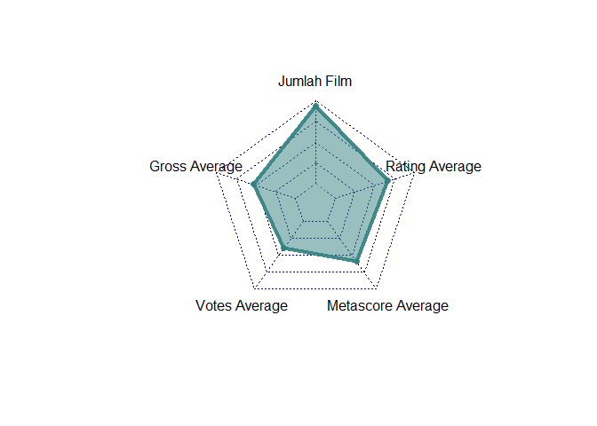

Radar Chart Steven Spielberg

```r
radarchart( y  , axistype=1, axislabcol = 'white', pcol=rgb(0.2,0.5,0.5,0.9) , pfcol=rgb(0.2,0.5,0.5,0.5),
            plwd = 4)
```

### Film dan Radar Chart Christopher Nolan

```r
df_nolan <- df %>%
  filter(Director == "Christopher Nolan") %>%
  select(Title, Rating, Metascore, Gross, Votes)
formattable(df_nolan,
            list(area(col = c(Metascore)) ~ normalize_bar("pink", 0.9),
                 area(col = c(Gross)) ~ normalize_bar("orange", 0.5),
                 area(col = c(Rating)) ~ normalize_bar("yellow", 0.9),
                 area(col = c(Votes)) ~ normalize_bar("#EFD05F", 0.9)
                 ))
```

| Title | Rating | Metascore | Gross | Votes |
| --- | --- | --- | --- | --- |
| The Dark Knight | 9.0 | 84 | 534.80 | 2294771 |
| The Dark Knight Rises | 8.4 | 78 | 448.10 | 1511587 |
| Inception | 8.8 | 74 | 292.50 | 2058745 |
| Batman Begins | 8.2 | 70 | 206.80 | 1304296 |
| Dunkirk | 7.8 | 94 | 188.30 | 552100 |
| Interstellar | 8.6 | 74 | 188.00 | 1503789 |
| The Prestige | 8.5 | 66 | 53.09 | 1185508 |
| Memento | 8.4 | 80 | 25.54 | 1122122 |

```r
rad <- radar_df %>%
  filter(Director=='Christopher Nolan') %>%
  select(`Cat JF`, `Cat GA`, `Cat VA`, `Cat MA`, `Cat RA`) %>%
  mutate_each(funs(as.numeric), c('Cat JF', 'Cat GA', 'Cat VA', 'Cat MA', 'Cat RA'))

a <- rep(c(15), times = 5)
l <- rep(c(0), times = 5)
n <- rbind.data.frame(a, l)
colnames(n) <- c('Cat JF', 'Cat GA', 'Cat VA', 'Cat MA', 'Cat RA')
y <- rbind.data.frame(n, rad)
v <- y %>%
  rename(`Jumlah Film` = `Cat JF`, `Gross Average` = `Cat GA`, `Metascore Average` = `Cat MA`,
         `Rating Average` = `Cat RA`, `Votes Average` = `Cat VA`)
```

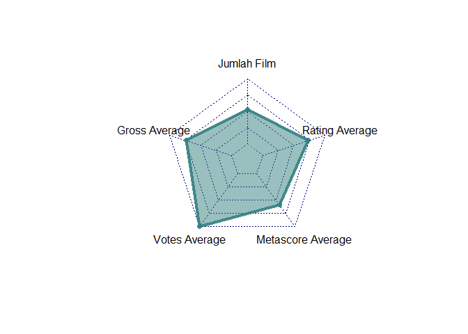

Radar Chart Christopher Nolan

```r
radarchart( v  , axistype=1, axislabcol = 'white', pcol=rgb(0.2,0.5,0.5,0.9) , pfcol=rgb(0.2,0.5,0.5,0.5),
            plwd = 4)
```

### Perbandingan Radar Chart 2 Top Director

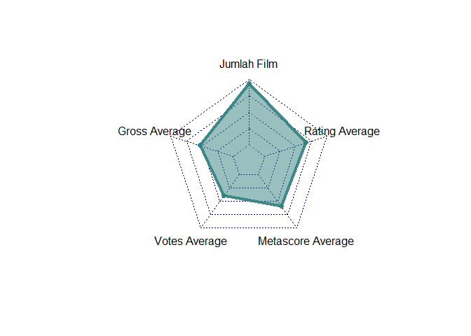

Radar Chart Steven Spielberg

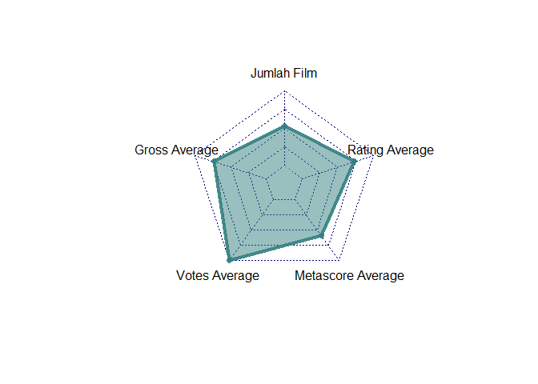

Radar Chart Christopher Nolan

Radar chart merupakan chart 2 dimensi yang berisi 5 variabel kuantitatif yang direpresentasikan pada sumbu yang dimulai dari titik yang sama. Kedua director diatas merupakan director terbaik di dunia, namun kedua director memiliki capaian yang berbeda dalam hal jumlah film dan votes average. Steven Spielberg memiliki jumlah film yang lebih banyak yang masuk ke Top 500 IMDB Box Office, sementara Christopher Nolan walaupun jumlah filmnya tidak sebanyak Steven Spielberg, Christopher Nolan memiliki angka votes average yang lebih tinggi.

## 3. Clustering

### Metode Elbow

Dalam metode elbow, varians (*within-cluster sum of square errors*) diplotkan terhadap jumlah cluster. Beberapa cluster pertama akan menunjukkan banyak variasi dan informasi, tetapi pada titik tertentu, perolehan informasi akan menjadi rendah, sehingga memberikan struktur sudut ke grafik. Jumlah cluster optimal ditemukan dari titik ini; oleh karena itu, ini dikenal sebagai “*elbow criterion*”.

$SSE=\sum_{K=1}^{K}\sum_{x_i\in S_K}\left|\left|X_i-C_k\right|\right|_2^2$

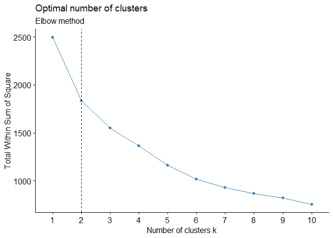

```r
data=df %>%
  select(Rating, Votes, Gross, Runtime, Metascore)

data_scaled=scale(data)
fviz_nbclust(data_scaled, kmeans, method="wss")+
  geom_vline(xintercept = 2, linetype=2)+
  labs(subtitle = "Elbow method")
```

Gambar menunjukkan hasil penentuan jumlah kluster menggunakan metode Elbow. Dari gambar diatas dapat diketahui bahwa nilai yang optimal untuk jumlah kluster adalah 2, terlihat dari elbow atau patahan garis yang berada di k = 2.

### Metode Average Silhouette Width

Dalam metode average silhouette width, nilai siluet untuk setiap titik data dihitung, yang meannya digunakan untuk menemukan jumlah cluster yang optimal. Nilai silhouette menunjukkan kemiripan titik data dengan clusternya sendiri jika dibandingkan dengan semua cluster atau pusat cluster lainnya. Nilainya berkisar dari -1 hingga +1. Nilai siluet yang lebih tinggi menyiratkan bahwa titik data cocok dengan pusat / klusternya sendiri dan tidak begitu cocok dengan kluster lain. Jika mean dari nilai silhouette yang diukur untuk semua titik data cukup tinggi, maka dapat dikatakan jumlah cluster berada pada nilai optimalnya, atau dengan kata lain struktur clustering sudah sesuai.

Untuk menemukan nilai siluet, metrik jarak apa pun, seperti jarak Minkowski atau jarak Euclidean, dapat digunakan :

$s\left(i\right)=\frac{b\left(i\right)-a\left(i\right)}{\max{\left\{a\left(i\right),b\left(i\right)\right\}}}$

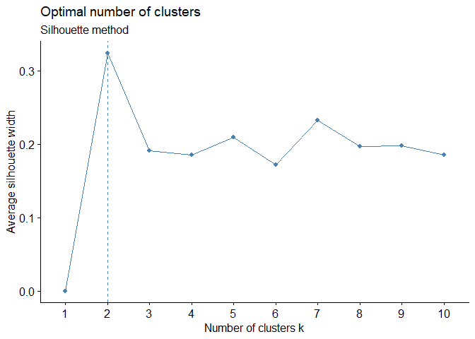

```r
fviz_nbclust(data_scaled, kmeans, method="silhouette")+
  labs(subtitle = "Silhouette method")
```

Gambar menunjukkan hasil penentuan jumlah kluster menggunakan metode Average Silhouette Width. Dari gambar diatas dapat diketahui nilai optimal untuk jumlah kluster adalah 2, terlihat dari nilai average silhouette width tertinggi di k = 2

### K-Means Clustering

K-means merupakan salah satu metode data klustering non hirarki yang berusaha mempartisi data yang ada ke dalam bentuk satu atau lebih cluster / kelompok. Metode ini mempartisi ke dalam cluster / kelompok sehingga data yang memiliki karakteristik yang sama (High intra class similarity) dikelompokkan ke dalam satu cluster yang sama dan yang memiliki karakteristik yang berbeda (Low inter class similarity) dikelompokkan pada kelompok yang lain.

Untuk melakukan penghitungan jarak data ke-i ($x_i$) pada pusat kluster ke-k ($c_k$), diberi nama ($d_{ik}$), dapat digunakan formula Euclidean : $d_{ik}=\sqrt{\left(\sum_{j=1}^{m}\left(x_{ij}-c_{kj}\right)^2\right)}$

Suatu data akan menjadi anggota dari kluster ke-k apabila jarak data tersebut ke pusat kluster ke-k bernilai paling kecil jika dibandingkan dengan jarak ke pusat kluster lainnya. Hal ini dapat dihitung dengan menggunakan :

$Min\sum_{k=1}^{k}d_{ik}=\sqrt{\left(\sum_{j=1}^{m}\left(x_{ij}-c_{kj}\right)^2\right)}$

Nilai pusat kluster yang baru dapat dihitung dengan cara mencari nilai rata-rata dari data-data yang menjadi anggota pada kluster tersebut, dengan menggunakan rumus pada persamaan berikut:

$c_{kj}=\frac{\sum_{i=1}^{p}x_{ij}}{p}$

Dimana $x_{ij}$ ∈ kluster ke–k dan p = banyaknya anggota kluster ke k.

Algoritma dasar dalam k-means clustering adalah sebagai berikut: 1. Tentukan jumlah kluster (k), tetapkan pusat kluster sembarang. 2. Hitung jarak setiap data ke pusat kluster menggunakan jarak euclidean. 3. Kelompokkan data ke dalam kluster berdasarkan jarak terpendek. 4. Hitung pusat kluster menggunakan nilai rata-rata dari data yang sudah terkluster. 5. Ulangi langkah 2 sampai dengan 4 hingga sudah tidak ada lagi data yang berpindah ke kluster yang lain.

```r
model=kmeans(data_scaled, centers=2)
data_clustered = mutate(data, cluster=model$cluster)
data_clustered$cluster <- as.character(data_clustered$cluster)
```

### Karakteristik dan Visualisasi CLuster

```r
cluster1 <- data_clustered %>% filter(cluster == 1) %>% rename(cluster1 = cluster)
cluster2 <- data_clustered %>% filter(cluster == 2) %>% rename(cluster2 = cluster)
```

```r
summary(cluster1)
```

```
##      Rating          Votes            Gross           Runtime
##  Min.   :7.600   Min.   : 27549   Min.   : 10.63   Min.   : 76.0
##  1st Qu.:7.700   1st Qu.:139920   1st Qu.: 27.30   1st Qu.:105.0
##  Median :7.800   Median :262623   Median : 52.93   Median :120.0
##  Mean   :7.827   Mean   :303080   Mean   : 84.57   Mean   :122.7
##  3rd Qu.:8.000   3rd Qu.:442612   3rd Qu.:111.50   3rd Qu.:135.0
##  Max.   :8.500   Max.   :798442   Max.   :608.50   Max.   :212.0
##    Metascore        cluster1
##  Min.   : 28.00   Length:401
##  1st Qu.: 69.00   Class :character
##  Median : 77.00   Mode  :character
##  Mean   : 75.98
##  3rd Qu.: 84.00
##  Max.   :100.00
```

```r
summary(cluster2)
```

```
##      Rating          Votes             Gross           Runtime
##  Min.   :7.800   Min.   : 267196   Min.   : 13.09   Min.   : 81.0
##  1st Qu.:8.100   1st Qu.: 756682   1st Qu.: 77.25   1st Qu.:116.5
##  Median :8.300   Median : 935385   Median :183.60   Median :136.0
##  Mean   :8.363   Mean   :1011159   Mean   :221.46   Mean   :138.6
##  3rd Qu.:8.500   3rd Qu.:1181986   3rd Qu.:312.30   3rd Qu.:152.5
##  Max.   :9.300   Max.   :2333529   Max.   :936.60   Max.   :238.0
##    Metascore        cluster2
##  Min.   : 57.00   Length:99
##  1st Qu.: 69.00   Class :character
##  Median : 80.00   Mode  :character
##  Mean   : 79.19
##  3rd Qu.: 89.00
##  Max.   :100.00
```

### Bar Chart Genre Film Menurut Cluster

```r
df_clus <- mutate(df, cluster=model$cluster)
df_long <- gather(df_clus, genre_, Genre, Genre_1:Genre_3, factor_key = TRUE)
df_long <- df_long %>% drop_na()
df_long$cluster <- as.character(df_long$cluster)
p <- ggplot(df_long, aes(Genre, fill = cluster)) + geom_bar(position = position_dodge(0.5)) +
  theme(aspect.ratio=6/5, panel.grid = element_blank(), rect = element_blank(),
        title = element_text(color = "#1B3A4B"),
        plot.title = element_text(size = 18, face = "bold"),
        text = element_text(size = 12),
        plot.caption = element_text(size = 8)) +
  coord_flip() +
  labs(x = "Genre Film", y = "Jumlah Film",
       title = "Genre Film Menurut Cluster",
       caption = "Data IMDB Top 500 Box Office")
ggplotly(p)
```

[interactive chart not shown]

Gambar menunjukkan visualisasi bar chart jumlah genre film berdasarkan cluster. Dapat diketahui bahwa film dengan genre sport dan musical masuk di cluster 1, sementara film dengan genre lainnya tersebar ke kedua cluster.

### Scatterplot Metascore vs Votes

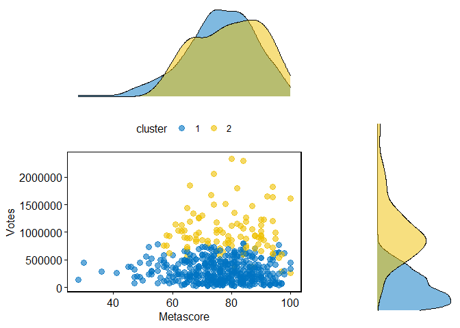

```r
sp <- ggscatter(data_clustered, x = "Metascore", y = "Votes",
                color = "cluster", palette = "jco",
                size = 3, alpha = 0.6)+
  border()
# Marginal density plot of x (top panel) and y (right panel)
xplot <- ggdensity(data_clustered, "Metascore", fill = "cluster",
                   palette = "jco")
yplot <- ggdensity(data_clustered, "Votes", fill = "cluster",
                   palette = "jco")+
  rotate()
# Cleaning the plots
# sp <- sp + rremove("legend")
yplot <- yplot + clean_theme() + rremove("legend")
xplot <- xplot + clean_theme() + rremove("legend")
#  Arranging the plot using cowplot

plot_grid(xplot, NULL, sp, yplot, ncol = 2, align = "hv",
          rel_widths = c(2, 1), rel_heights = c(1, 2))
```

### Scatterplot Runtime vs Gross

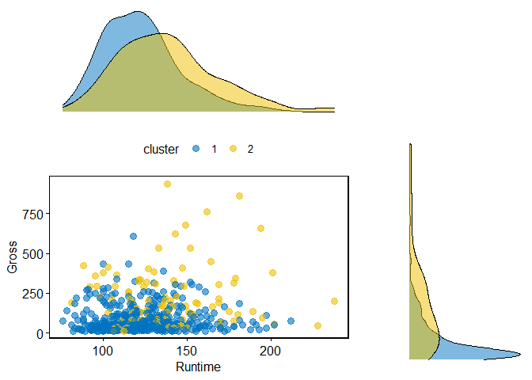

```r
sp <- ggscatter(data_clustered, x = "Runtime", y = "Gross",
                color = "cluster", palette = "jco",
                size = 3, alpha = 0.6)+
  border()
# Marginal density plot of x (top panel) and y (right panel)
xplot <- ggdensity(data_clustered, "Runtime", fill = "cluster",
                   palette = "jco")
yplot <- ggdensity(data_clustered, "Gross", fill = "cluster",
                   palette = "jco")+
  rotate()
# Cleaning the plots
# sp <- sp + rremove("legend")
yplot <- yplot + clean_theme() + rremove("legend")
xplot <- xplot + clean_theme() + rremove("legend")
#  Arranging the plot using cowplot

plot_grid(xplot, NULL, sp, yplot, ncol = 2, align = "hv",
          rel_widths = c(2, 1), rel_heights = c(1, 2))
```

## Saran dan Rekomendasi

Saran dan rekomendasi yang dapat penulis berikan untuk penelitian selanjutnya diantaranya melakukan analisis eksplorasi data yang lebih dalam untuk mendapatkan informasi yang lebih banyak dari data yang bisa didapatkan dengan web scraping karena penulis belum mengeksplor semua variabel yang dapat di scraping, seperti variabel Aktor, Sinopsis, dan klasifikasi batas usia minimal film. Selain itu penelitian selanjutnya diharapkan melakukan eksplorasi metode analisis cluster lain yang melibatkan variabel-variabel kategorik sebagai variabel penentuan kluster.

Berdasarkan laman IMDb yang digunakan penulis untuk mengumpulkan data Top 1000 IMDB US Box Office Movies hanya terdapat 581 film yang memiliki data Metascore. Mengingat bahwa data tersebut adalah 1000 film teratas versi IMDb, penulis merekomendasikan IMDB sebagai penyedia informasi film dan acara televisi yang populer agar mengumpulkan kritik dan review film dari kritikus-kritikus terpercaya agar dapat melengkapi data Metascore pada film-film yang belum memiliki Metascore.